# Laboratory Session - May 19, 2022

# Paolo Zinesi 2053062

```r
set.seed(12345)

library(tidyverse)
library(gridExtra)
library(rstan)
library(rjags)
library(brms)

cbPalette <- c("#000000", "#E69F00", "#56B4E9", "#009E73", "#F0E442", "#0072B2", "#D55E00", "#CC79A7")
```

## Exercise 1

A well established and diffused method for detecting a disease in blood fails to detect the presence of disease in 15% of the patients that actually have the disease. A young UniPD startUp has developed an innovative method of screening. During the qualification phase, a random sample of $n = 75$ patients known to have the disease is screened using the new method.

### Exercise 1a

**What is the probability distribution of y, the number of times the new method fails to detect the disease?**

The variable $y$ follows a Binomial distribution on the parameter $p$, which quantify the probability of failing to detect the disease if a patient has the disease, and on the total number of measurements $n$. The likelihood associated to $y$ given $p$ and $n$ is

$$\mathcal{L}(y\,|\,p,n) = {n \choose y}\,
p^y\,(1-p)^{n-y}$$

### Exercise 1b

On the $n = 75$ patients sample, the new method fails to detect the disease in $y = 6$ cases. What is the frequentist estimator of the failure probability of the new method?

```r
y1 <- 6
n1 <- 75
p_1_F <- y1/n1
cat("Frequentist estimator of the failure probability for y=", y1, " and n=", n1, " is p = ", signif(p_1_F, digits=3), sep="")
```

```
Frequentist estimator of the failure probability for y=6 and n=75 is p = 0.08
```

### Exercise 1c

Setup a Bayesian computation of the posterior probability, assuming a beta distribution with mean value 0.15 and standard deviation 0.14. Plot the posterior distribution of the probability of y, and mark on the plot the mean value and variance.

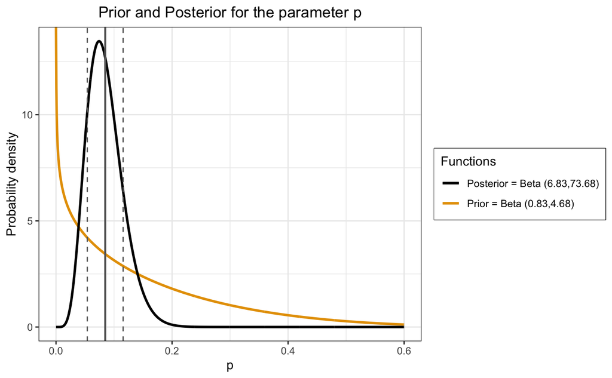

```r
# estimate parameters for beta prior
p <- seq(0, 0.6, length.out=1001)
mean_beta1 <- 0.15
var_beta1 <- (0.14)**2
a1_prior <- ((1 - mean_beta1)/var_beta1 - 1/mean_beta1) * (mean_beta1**2)
b1_prior <- a1_prior * (1/mean_beta1 - 1)
beta_prior1_df <- tibble(p=p, y=dbeta(p, a1_prior, b1_prior))

# likelihood(y/p,n) = Binom(y|p,n)

# estimate parameters for beta posterior
a1_post <- a1_prior + y1
b1_post <- b1_prior + n1 - y1
beta_post1_df <- tibble(p=p, y=dbeta(p, a1_post, b1_post))
mean_beta1_post <- a1_post/(a1_post+b1_post)
var_beta1_post <- (a1_post*b1_post)/(((a1_post+b1_post)**2)*(a1_post+b1_post+1))

# plot
plt1_prior_post <-  ggplot() +
                    labs(title="Prior and Posterior for the parameter p", colour="Functions") +
                    geom_line(data=beta_prior1_df, aes(x = p, y = y,colour=paste0("Prior = Beta (",round(a1_prior,2),",",round(b1_prior,2),")")), size=1) +
                    geom_line(data=beta_post1_df, aes(x = p, y = y, colour=paste0("Posterior = Beta (",round(a1_post,2),",",round(b1_post,2),")")), size=1) +
                    geom_vline(xintercept = mean_beta1_post, colour="grey40", linetype="solid", size=0.8) +
                    geom_vline(xintercept = c(mean_beta1_post+sqrt(var_beta1_post), mean_beta1_post-sqrt(var_beta1_post)),
                               colour="grey40", linetype="dashed") +
                    scale_y_continuous(name = "Probability density") +
                    scale_colour_manual(values = cbPalette) +
                    theme_bw() +
                    theme(plot.title=element_text(hjust=0.5), legend.box.background = element_rect(size=0.4))

plt1_prior_post
```

### Exercise 1d

Perform a test of hypothesis assuming that if the probability of failing to detect the disease in ill patients is greater or equal than 15%, the new test is no better that the traditional method. Test the sample at a 5% level of significance in the Bayesian way.

The two hypothesis are
$$H_0 : p \geq 0.15
\text{ versus } H_1 : p < 0.15$$

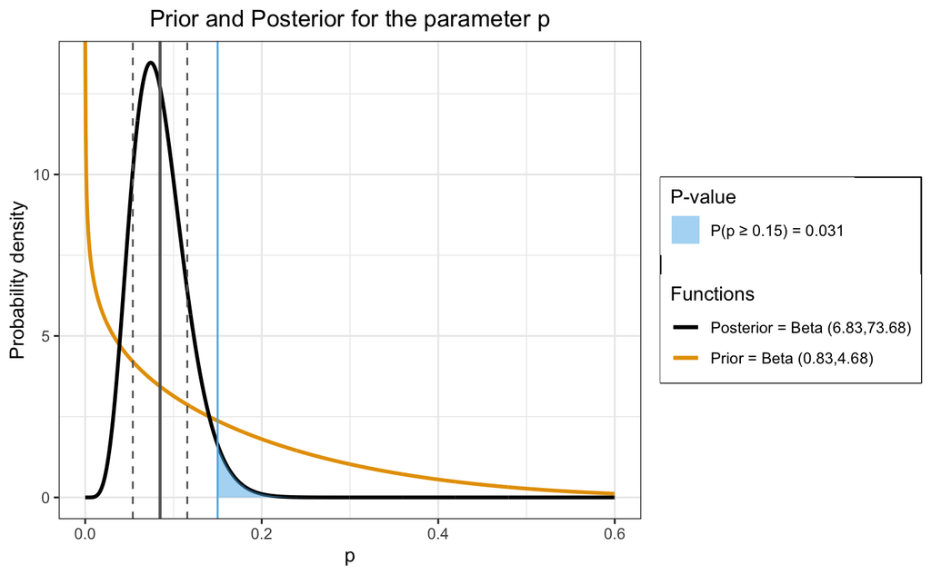

```r
# compute p-value
Pval1_B <- 1 - pbeta(0.15, a1_post, b1_post)

# plot
plt1_pval_B <-  plt1_prior_post +
                labs(fill="P-value") +
                geom_area(data=beta_post1_df, aes(x=ifelse(p>=0.15, p, NA), fill = paste0("P(p ≥ 0.15) = ", round(Pval1_B,3)), y=y), alpha = 0.5) +
                geom_vline(xintercept = 0.15, colour=cbPalette[3]) +
                scale_fill_manual(values=cbPalette[3])
plt1_pval_B
```

**Since the P-value is smaller than the significance level $\alpha=0.05$, we reject the null hypothesis. The new test is, thus, more effective in detecting the disease with the Bayesian hypothesis testing.**

### Exercise 1e

Perform the same hypothesis test in the classical frequentist way.

The null distribution is the binomial with $n=75$ and $p=0.15$.

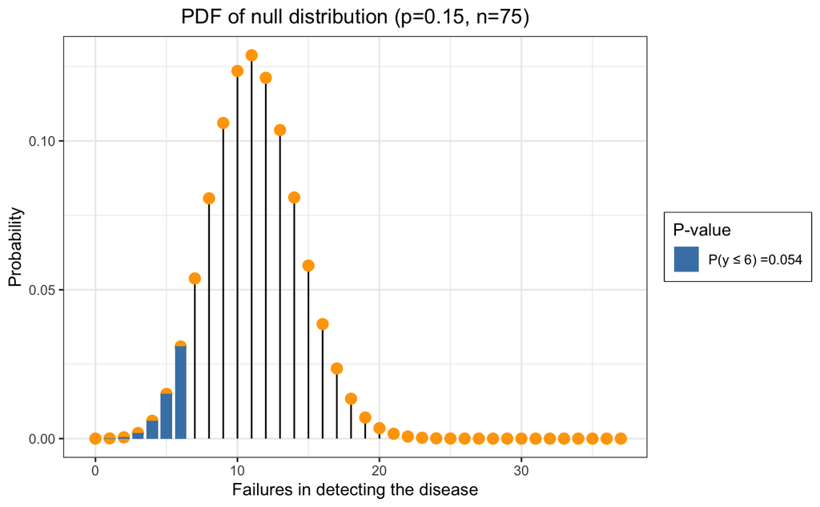

```r
# compute p-value
Pval1_F <- pbinom(y1, n1, 0.15)

# plot
null_distr1 <- tibble(x=seq(from=0, to=n1/2), y=dbinom(x=seq(from=0, to=n1/2), size=n1, prob=0.15))
plt1_pval_F <-  ggplot(null_distr1, aes(x=x, y=y)) +
                labs(title=paste0("PDF of null distribution (p=0.15, n=", n1, ")"), fill="P-value") +
                geom_segment(aes(x=x, xend=x, y=0, yend=y)) +
                geom_point(size=3, color='orange') +
                geom_col(data=null_distr1,
                         aes(x=ifelse(x<=y1, x, 0), y=ifelse(x<=y1, y, 0), fill=paste0("P(y ≤ ", y1, ") =", round(Pval1_F,3))),
                         alpha=1, size=0.5, width = 0.8) +
                scale_x_continuous(name ="Failures in detecting the disease") +
                scale_y_continuous(name ="Probability") +
                scale_fill_manual(values="steelblue") +
                theme_bw() +
                theme(plot.title=element_text(hjust=0.5), legend.box.background = element_rect(size=0.4))
plt1_pval_F
```

**Since the P-value is larger than the significance level $\alpha=0.05$, we cannot reject the null hypothesis. In principle, according to frequentist hypothesis testing, the observed value of $y$ could be a random fluctuation at the significance level $\alpha=0.05$**.

## Exercise 2

Ladislaus Josephovich Bortkiewicz was a Russian economist and statistician. He noticed that the Poisson distribution can be very useful in applied statistics when describing low-frequency events in a large population. In a famous example he showed that the number of deaths by horse kick among the Prussian army follows the Poisson distribution. Considering the following two sets of observations taken over a fixed large time interval in two different corps:

```r
data2_display <- tibble("y death soldiers"=c("0","1","2","3","4","≥5"),
                "n1 observations"=c(109,65,22,3,1,0),
                "n2 observations"=c(144,91,32,11,2,0))
data2 <- tibble("y"=seq(0,4),
                "n1 observations"=c(109,65,22,3,1),
                "n2 observations"=c(144,91,32,11,2))
# extended data
data2_corp1 <- rep(x=data2[["y"]], times=data2[["n1 observations"]])
data2_corp2 <- rep(x=data2[["y"]], times=data2[["n2 observations"]])

data2_display
```

| y death soldiers | n1 observations | n2 observations |
| --- | --- | --- |
| 0 | 109 | 144 |
| 1 | 65 | 91 |
| 2 | 22 | 32 |
| 3 | 3 | 11 |
| 4 | 1 | 2 |
| ≥5 | 0 | 0 |

The prior is denoted as $P \left( \lambda\, |\, n,M \right)$, the likelihood is denoted as $\mathcal{L} \left( y\, |\, \lambda,n,M \right)$ and the posterior is denoted as $\mathcal{P} \left( \lambda\, |\, y,n,M \right)$. Bayes’ theorem states that
$$\mathcal{P} \left( \lambda\, |\, y,n,M \right) =
\dfrac{1}{Z}\, \mathcal{L} \left( y\, |\, \lambda,n,M \right)\, P \left(
\lambda\, |\, n,M \right),$$
where $Z$ is a normalization constant.

### Exercise 2a

Assuming a uniform prior, compute and plot the posterior distribution for $\lambda$, the death rate over the measurement time. Determine the posterior mean, median and variance, and compute the 95% credibility interval.

A uniform prior is a $\text{Gamma}(1,0)$, the likelihood is $\mathcal{L} \left( y\, |\, \lambda,n,M \right) = \prod_i \dfrac{\lambda^{y_i}\,e^{-\lambda}}{y_i!}$ and the posterior is a $\text{Gamma}(1+\sum_i y_i,n)$.

```r
# grid of lambdas
lambda <- seq(0, 1, length.out=1001)

# summaries of data
n_corp1 <- sum(data2["n1 observations"])
n_corp2 <- sum(data2["n2 observations"])
y_corp1 <- sum(data2["y"]*data2["n1 observations"])
y_corp2 <- sum(data2["y"]*data2["n2 observations"])

# uniform prior parameters
a_u_prior <- 1
r_u_prior <- 0

# posteriors parameters
a_corp1_u_post <- a_u_prior + y_corp1
r_corp1_u_post <- r_u_prior + n_corp1
a_corp2_u_post <- a_u_prior + y_corp2
r_corp2_u_post <- r_u_prior + n_corp2
mean_corp1_u <- a_corp1_u_post / r_corp1_u_post
mean_corp2_u <- a_corp2_u_post / r_corp2_u_post
median_corp1_u <- qgamma(0.5, shape=a_corp1_u_post, rate=r_corp1_u_post)
median_corp2_u <- qgamma(0.5, shape=a_corp2_u_post, rate=r_corp2_u_post)
var_corp1_u <- a_corp1_u_post / (r_corp1_u_post**2)
var_corp2_u <- a_corp2_u_post / (r_corp2_u_post**2)
CI_corp1_u <- c(qgamma(0.025, shape=a_corp1_u_post, rate=r_corp1_u_post),
                qgamma(0.975, shape=a_corp1_u_post, rate=r_corp1_u_post))
CI_corp2_u <- c(qgamma(0.025, shape=a_corp2_u_post, rate=r_corp2_u_post),
                qgamma(0.975, shape=a_corp2_u_post, rate=r_corp2_u_post))

# posterior dfs (with analytical update rules)
corp1_u_post_df <- tibble(lambda=lambda, y=dgamma(lambda, shape=a_corp1_u_post, rate=r_corp1_u_post))
corp2_u_post_df <- tibble(lambda=lambda, y=dgamma(lambda, shape=a_corp2_u_post, rate=r_corp2_u_post))
```

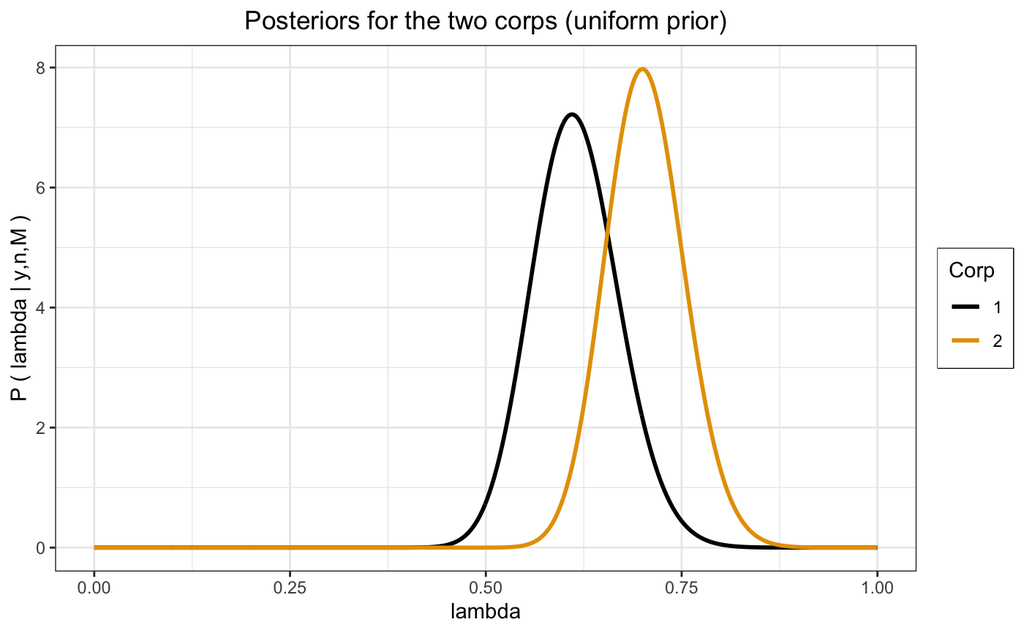

```r
# posteriors plot
plt2_u_post <-  ggplot(mapping = aes(y=y)) +
                labs(title="Posteriors for the two corps (uniform prior)", colour="Corp") +
                geom_line(data=corp1_u_post_df, aes(x=lambda, colour="1"), size=1) +
                geom_line(data=corp2_u_post_df, aes(x=lambda, colour="2"), size=1) +
                scale_y_continuous(name = "P ( lambda | y,n,M )") +
                scale_colour_manual(values = cbPalette) +
                theme_bw() +
                theme(plot.title=element_text(hjust=0.5), legend.box.background = element_rect(size=0.4))

plt2_u_post
```

```r
cat(
  "Corp 1: mean=", signif(mean_corp1_u, 3), ", median=", signif(median_corp1_u, 3), ", variance=", signif(var_corp1_u, 3), "\n",
  "\t95% credibility interval=[", signif(CI_corp1_u[1],3), ",", signif(CI_corp1_u[2],3), "]\n",

  "Corp 2: mean=", signif(mean_corp2_u, 3), ", median=", signif(median_corp2_u, 3), ", variance=", signif(var_corp2_u, 3), "\n",
  "\t95% credibility interval=[", signif(CI_corp2_u[1],3), ",", signif(CI_corp2_u[2],3), "]\n",
  sep="")
```

```
Corp 1: mean=0.615, median=0.613, variance=0.00308
    95% credibility interval=[0.511,0.728]
Corp 2: mean=0.704, median=0.702, variance=0.00251
    95% credibility interval=[0.609,0.805]
```

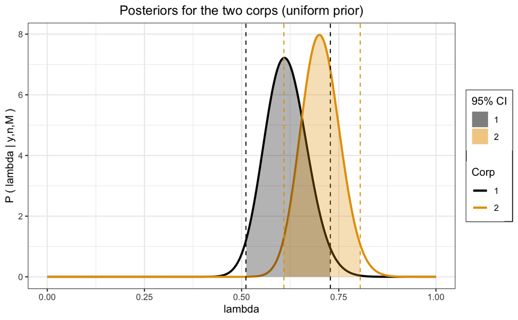

```r
plt2_u_CI <-  plt2_u_post +
              geom_vline(xintercept = CI_corp1_u, colour=cbPalette[1], linetype="dashed") +
              geom_area(data=corp1_u_post_df, aes(x=ifelse(lambda>=CI_corp1_u[1] & lambda<=CI_corp1_u[2], lambda, NA), fill = "1"), alpha = 0.3) +
              geom_vline(xintercept = CI_corp2_u, colour=cbPalette[2], linetype="dashed") +
              geom_area(data=corp2_u_post_df, aes(x=ifelse(lambda>=CI_corp2_u[1] & lambda<=CI_corp2_u[2], lambda, NA), fill = "2"), alpha = 0.3) +
              labs(fill="95% CI") +
              scale_fill_manual(values=cbPalette)

plt2_u_CI
```

### Exercise 2b

Assuming now a Jeffrey’s prior,

$$g\,(\lambda) \propto
\dfrac{1}{\sqrt{\lambda}}, \text{ with } \lambda>0$$

Compute and plot the posterior distribution for $\lambda$, the death rate over the measurement time. Determine the posterior mean, median and variance, and compute the 95% credibility interval.

A Jeffrey’s prior is a $\text{Gamma}\left(\dfrac{1}{2},0\right)$, the likelihood is $\mathcal{L} \left( y\, |\, \lambda,n,M \right) = \prod_i \dfrac{\lambda^{y_i}\,e^{-\lambda}}{y_i!}$ and the posterior is a $\text{Gamma}\left(\dfrac{1}{2}+\sum_i y_i,n\right)$.

```r
# uniform prior parameters
a_J_prior <- 0.5
r_J_prior <- 0

# posteriors parameters
a_corp1_J_post <- a_J_prior + y_corp1
r_corp1_J_post <- r_J_prior + n_corp1
a_corp2_J_post <- a_J_prior + y_corp2
r_corp2_J_post <- r_J_prior + n_corp2
mean_corp1_J <- a_corp1_J_post / r_corp1_J_post
mean_corp2_J <- a_corp2_J_post / r_corp2_J_post
median_corp1_J <- qgamma(0.5, shape=a_corp1_J_post, rate=r_corp1_J_post)
median_corp2_J <- qgamma(0.5, shape=a_corp2_J_post, rate=r_corp2_J_post)
var_corp1_J <- a_corp1_J_post / (r_corp1_J_post**2)
var_corp2_J <- a_corp2_J_post / (r_corp2_J_post**2)
CI_corp1_J <- c(qgamma(0.025, shape=a_corp1_J_post, rate=r_corp1_J_post),
                qgamma(0.975, shape=a_corp1_J_post, rate=r_corp1_J_post))
CI_corp2_J <- c(qgamma(0.025, shape=a_corp2_J_post, rate=r_corp2_J_post),
                qgamma(0.975, shape=a_corp2_J_post, rate=r_corp2_J_post))

# posterior dfs (with analytical update rules)
corp1_J_post_df <- tibble(lambda=lambda, y=dgamma(lambda, shape=a_corp1_J_post, rate=r_corp1_J_post))
corp2_J_post_df <- tibble(lambda=lambda, y=dgamma(lambda, shape=a_corp2_J_post, rate=r_corp2_J_post))
```

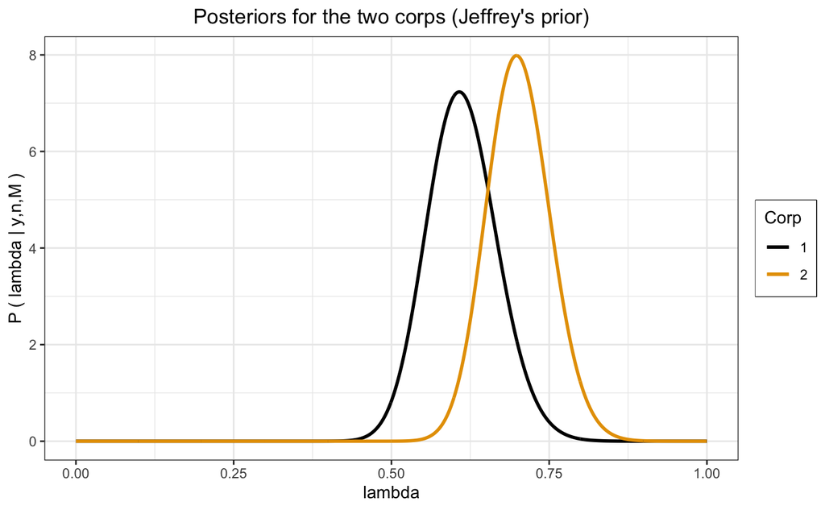

```r
# posteriors plot
plt2_J_post <-  ggplot(mapping = aes(y=y)) +
                labs(title="Posteriors for the two corps (Jeffrey's prior)", colour="Corp") +
                geom_line(data=corp1_J_post_df, aes(x=lambda, colour="1"), size=1) +
                geom_line(data=corp2_J_post_df, aes(x=lambda, colour="2"), size=1) +
                scale_y_continuous(name = "P ( lambda | y,n,M )") +
                scale_colour_manual(values = cbPalette) +
                theme_bw() +
                theme(plot.title=element_text(hjust=0.5), legend.box.background = element_rect(size=0.4))

plt2_J_post
```

```r
cat(
  "Corp 1: mean=", signif(mean_corp1_J, 3), ", median=", signif(median_corp1_J, 3), ", variance=", signif(var_corp1_J, 3), "\n",
  "\t95% credibility interval=[", signif(CI_corp1_J[1],3), ",", signif(CI_corp1_J[2],3), "]\n",

  "Corp 2: mean=", signif(mean_corp2_J, 3), ", median=", signif(median_corp2_J, 3), ", variance=", signif(var_corp2_J, 3), "\n",
  "\t95% credibility interval=[", signif(CI_corp2_J[1],3), ",", signif(CI_corp2_J[2],3), "]\n",
  sep="")
```

```
Corp 1: mean=0.612, median=0.611, variance=0.00306
    95% credibility interval=[0.509,0.726]
Corp 2: mean=0.702, median=0.701, variance=0.00251
    95% credibility interval=[0.607,0.803]
```

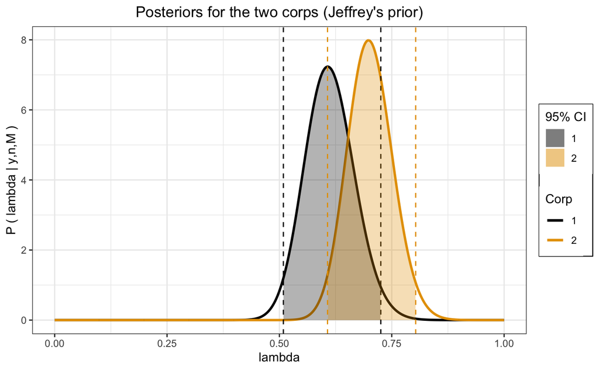

```r
plt2_J_CI <-  plt2_J_post +
              geom_vline(xintercept = CI_corp1_J, colour=cbPalette[1], linetype="dashed") +
              geom_area(data=corp1_J_post_df, aes(x=ifelse(lambda>=CI_corp1_J[1] & lambda<=CI_corp1_J[2], lambda, NA), fill = "1"), alpha = 0.3) +
              geom_vline(xintercept = CI_corp2_J, colour=cbPalette[2], linetype="dashed") +
              geom_area(data=corp2_J_post_df, aes(x=ifelse(lambda>=CI_corp2_J[1] & lambda<=CI_corp2_J[2], lambda, NA), fill = "2"), alpha = 0.3) +
              labs(fill="95% CI") +
              scale_fill_manual(values=cbPalette)

plt2_J_CI
```

## Exercise 3

In a study on water quality of streams, a high level of bacteria X was defined as a level greater than 100 per 100 ml of stream water. $n = 116$ samples were taken from streams having a high environmental impact on pandas. Out of these, $y = 11$ had a high bacteria X level. Indicate with $p$ the probability that a sample of water taken from the stream has a high bacteria X level.

### Exercise 3a

Find the frequentist estimator for $p$.

```r
y3a <- 11
n3a <- 116
p_3a_F <- y3a/n3a
cat("Frequentist estimator of the failure probability for y=", y3a, " and n=", n3a, " is p = ", signif(p_3a_F, digits=3), sep="")
```

```
Frequentist estimator of the failure probability for y=11 and n=116 is p = 0.0948
```

### Exercise 3b

Using a Beta(1, 10) prior for $p$, calculate the posterior distribution $P(p \,|\, y,n,M)$.

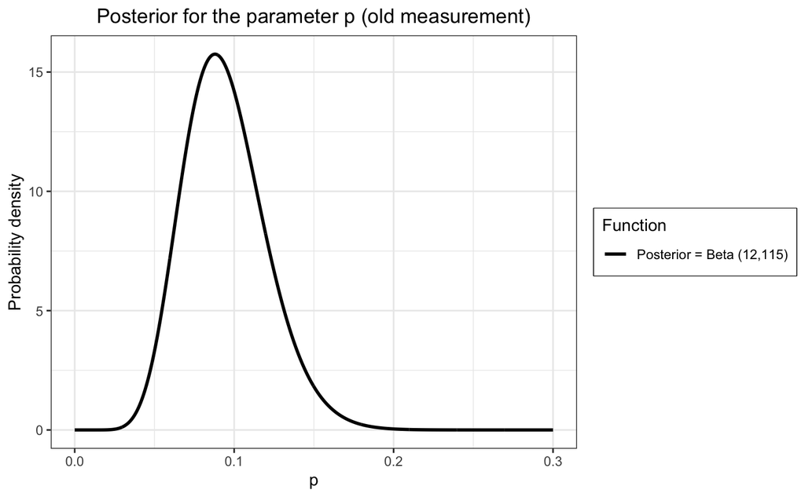

```r
# Beta(1,10) prior parameters
p <- seq(0, 0.3, length.out=1001)
a3_prior <- 1
b3_prior <- 10
beta_prior3a_df <- tibble(p=p, y=dbeta(p, a3_prior, b3_prior))

# posteriors parameters
a3a_post <- a3_prior + y3a
b3a_post <- b3_prior + n3a - y3a
beta_post3a_df <- tibble(p=p, y=dbeta(p, a3a_post, b3a_post))

# plot
plt3_post <-  ggplot(mapping=aes(y=y)) +
              labs(title="Posterior for the parameter p (old measurement)", colour="Function") +
              geom_line(data=beta_post3a_df, aes(x=p, colour=paste0("Posterior = Beta (",round(a3a_post,2),",",round(b3a_post,2),")")), size=1) +
              scale_y_continuous(name = "Probability density") +
              scale_colour_manual(values = cbPalette[1]) +
              theme_bw() +
              theme(plot.title=element_text(hjust=0.5), legend.box.background = element_rect(size=0.4))

plt3_post
```

### Exercise 3c

Find the Bayesian estimator for $p$, the posterior mean and variance, and a 95% credible interval.

```r
# find Bayesian estimator as the maximum of the posterior
p_3a_B <- (a3a_post - 1)/(a3a_post + b3a_post - 2)
mean_3a <- a3a_post / (a3a_post + b3a_post)
var_3a <- (a3a_post*b3a_post)/(((a3a_post+b3a_post)**2)*(a3a_post+b3a_post+1))
CI_3a_B <- c(qbeta(0.025, a3a_post, b3a_post),
           qbeta(0.975, a3a_post, b3a_post))

cat("Bayesian estimate for p = ", signif(p_3a_B,3), ", mean=", signif(mean_3a, 3), ", variance=", signif(var_3a, 3), "\n",
    "\t95% credibility interval=[", signif(CI_3a_B[1],3), ",", signif(CI_3a_B[2],3), "]\n", sep="")
```

```
Bayesian estimate for p = 0.088, mean=0.0945, variance=0.000668
    95% credibility interval=[0.0502,0.151]
```

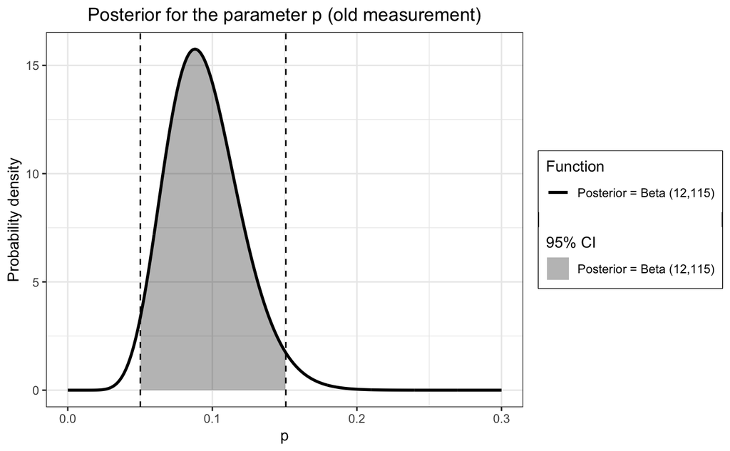

```r
# plot
plt3_CI <-  plt3_post +
            geom_vline(xintercept = CI_3a_B, colour=cbPalette[1], linetype="dashed") +
            geom_area(data=beta_post3a_df, alpha=0.3,
                      aes(x=ifelse(p>=CI_3a_B[1] & p<=CI_3a_B[2], p, NA),
                          fill=paste0("Posterior = Beta (",round(a3a_post,2),",",round(b3a_post,2),")"))) +
            labs(fill="95% CI") +
            scale_fill_manual(values=cbPalette)

plt3_CI
```

### Exercise 3d

Test the hypothesis
$$H_0 : p = 0.1 \text{
versus } H_1 : p \neq 0.1$$
at 5% level of significance with both the frequentist and Bayesian approach.

The null distribution used in the frequentist hypothesis testing is a binomial with $n=116$ and $p=0.1$.

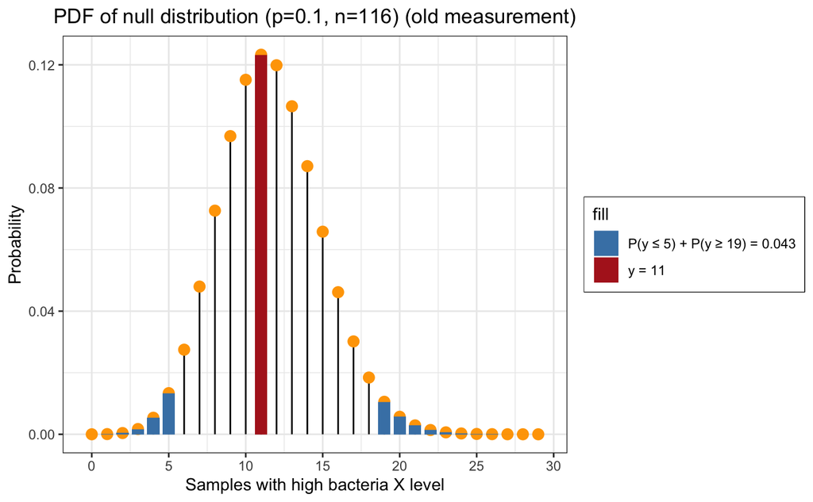

```r
# frequentist hypothesis testing
# these extreme values are the first ones belonging to the rejection region
CI_3a_F <- c(qbinom(0.025, size=n3a, prob=0.1)-1, qbinom(0.975, size=n3a, prob=0.1)+1)
signif_3a_F <- pbinom(CI_3a_F[1], size=n3a, prob=0.1) + pbinom(CI_3a_F[2]-1, size=n3a, prob=0.1, lower.tail=FALSE)

# plot
null_distr3 <- tibble(x=seq(from=0, to=n3a/4), y=dbinom(x=seq(from=0, to=n3a/4), size=n3a, prob=0.1))
plt3_pval_F <-  ggplot(data=null_distr3, mapping=aes(x=x, y=y)) +
                labs(title=paste0("PDF of null distribution (p=0.1, n=", n3a, ") (old measurement)"), fill="fill") +
                geom_segment(aes(x=x, xend=x, y=0, yend=y)) +
                geom_point(size=3, color='orange') +
                geom_col(mapping=aes(x=ifelse((x<=CI_3a_F[1] | x>=CI_3a_F[2]), x, 0),
                                     y=ifelse((x<=CI_3a_F[1] | x>=CI_3a_F[2]), y, 0),
                                     fill=paste0("P(y ≤ ", CI_3a_F[1], ") + P(y ≥ ", CI_3a_F[2], ") = ", round(signif_3a_F,3))),
                         alpha=1, size=0.5, width = 0.8) +
                geom_col(data=tibble(x=y3a, y=dbinom(y3a, size=n3a, prob=0.1)), mapping=aes(fill=paste0("y = ", y3a)),
                         alpha=1, size=0.5, width = 0.8) +
                scale_x_continuous(name ="Samples with high bacteria X level", breaks=seq(0,30,5)) +
                scale_y_continuous(name ="Probability") +
                scale_fill_manual(values=c("steelblue", "firebrick")) +
                theme_bw() +
                theme(plot.title=element_text(hjust=0.5), legend.box.background = element_rect(size=0.4))
plt3_pval_F
```

**Since the value of $y=11$ is inside the 95% frequentist confidence interval, we do not reject the null hypothesis at 5% level of significance in the frequentist approach. In the Bayesian hypothesis testing, instead, we employ the 95% credibility interval computed in the previous point (3c). The value of $p=0.1$ lies in the acceptance region, so we accept the null hypothesis (no significant change occurred in stream water). Both approaches lead to the same conclusions at 5% level of significance.**

A new measurement, performed one month later on $n = 165$ water samples, gives $y = 9$ high bacteria X level.

### Exercise 3e

Find the frequentist estimator for $p$.

```r
y3e <- 9
n3e <- 165
p_3e_F <- y3e/n3e
cat("Frequentist estimator of the failure probability for y=", y3e, " and n=", n3e, " is p = ", signif(p_3e_F, digits=3), sep="")
```

```
Frequentist estimator of the failure probability for y=9 and n=165 is p = 0.0545
```

### Exercise 3f

Find a Bayesian estimator for $p$, assuming both a Beta(1, 10) prior for $p$, and assuming the posterior probability of the older measurement as the prior for the new one.

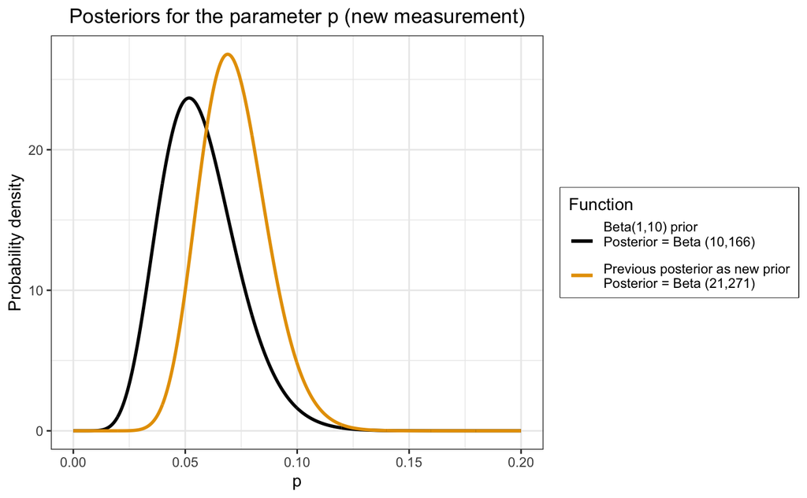

```r
# Beta(1,10) prior parameters
p <- seq(0, 0.2, length.out=1001)
a3_beta_prior <- 1
b3_beta_prior <- 10
beta_prior3e_df <- tibble(p=p, y=dbeta(p, a3_beta_prior, b3_beta_prior))

# posterior of point 3b as a new prior
a3_new_prior <- a3a_post
b3_new_prior <- b3a_post
new_prior3e_df <- tibble(p=p, y=dbeta(p, a3_new_prior, b3_new_prior))

# posteriors parameters
a3e_beta_post <- a3_beta_prior + y3e
b3e_beta_post <- b3_beta_prior + n3e - y3e
a3e_new_post <- a3_new_prior + y3e
b3e_new_post <- b3_new_prior + n3e - y3e
beta_post3e_df <- tibble(p=p, y=dbeta(p, a3e_beta_post, b3e_beta_post))
new_post3e_df <- tibble(p=p, y=dbeta(p, a3e_new_post, b3e_new_post))

# plot
plt3e_post <- ggplot(mapping=aes(y=y)) +
              labs(title="Posteriors for the parameter p (new measurement)", colour="Function") +
              geom_line(data=beta_post3e_df, aes(x=p,colour=paste0("Beta(", a3_beta_prior, ",", b3_beta_prior, ") prior\nPosterior = Beta (",round(a3e_beta_post,2),",",round(b3e_beta_post,2),")\n")), size=1) +
              geom_line(data=new_post3e_df, aes(x=p, colour=paste0("Previous posterior as new prior\nPosterior = Beta (",round(a3e_new_post,2),",",round(b3e_new_post,2),")")), size=1) +
              scale_y_continuous(name = "Probability density") +
              scale_colour_manual(values = cbPalette) +
              theme_bw() +
              theme(plot.title=element_text(hjust=0.5), legend.box.background = element_rect(size=0.4))

plt3e_post
```

### Exercise 3g

Find the Bayesian estimator for $p$, the posterior mean and variance, and a 95% credible interval.

```r
# find Bayesian estimator as the maximum of the posterior
p_3e_beta_B <- (a3e_beta_post - 1)/(a3e_beta_post + b3e_beta_post - 2)
p_3e_new_B <- (a3e_new_post - 1)/(a3e_new_post + b3e_new_post - 2)
mean_3e_beta <- a3e_beta_post / (a3e_beta_post + b3e_beta_post)
mean_3e_new <- a3e_new_post / (a3e_new_post + b3e_new_post)
var_3e_beta <- (a3e_beta_post*b3e_beta_post)/(((a3e_beta_post+b3e_beta_post)**2)*(a3e_beta_post+b3e_beta_post+1))
var_3e_new <- (a3e_new_post*b3e_new_post)/(((a3e_new_post+b3e_new_post)**2)*(a3e_new_post+b3e_new_post+1))
CI_3e_beta_B <- c(qbeta(0.025, a3e_beta_post, b3e_beta_post),
           qbeta(0.975, a3e_beta_post, b3e_beta_post))
CI_3e_new_B <- c(qbeta(0.025, a3e_new_post, b3e_new_post),
           qbeta(0.975, a3e_new_post, b3e_new_post))

cat(
  "With Beta(1,10) prior:\n\tBayesian estimate for p = ", signif(p_3e_beta_B,3),
  ", mean=", signif(mean_3e_beta, 3), ", variance=", signif(var_3e_beta, 3), "\n",
  "\t95% credibility interval=[", signif(CI_3e_beta_B[1],3), ",", signif(CI_3e_beta_B[2],3), "]\n",

  "With previous posterior as a new prior:\n\tBayesian estimate for p = ", signif(p_3e_new_B,3),
  ", mean=", signif(mean_3e_new, 3), ", variance=", signif(var_3e_new, 3), "\n",
  "\t95% credibility interval=[", signif(CI_3e_new_B[1],3), ",", signif(CI_3e_new_B[2],3), "]\n",
  sep="")
```

```
With Beta(1,10) prior:
    Bayesian estimate for p = 0.0517, mean=0.0568, variance=0.000303
    95% credibility interval=[0.0277,0.0954]
With previous posterior as a new prior:
    Bayesian estimate for p = 0.069, mean=0.0719, variance=0.000228
    95% credibility interval=[0.0452,0.104]
```

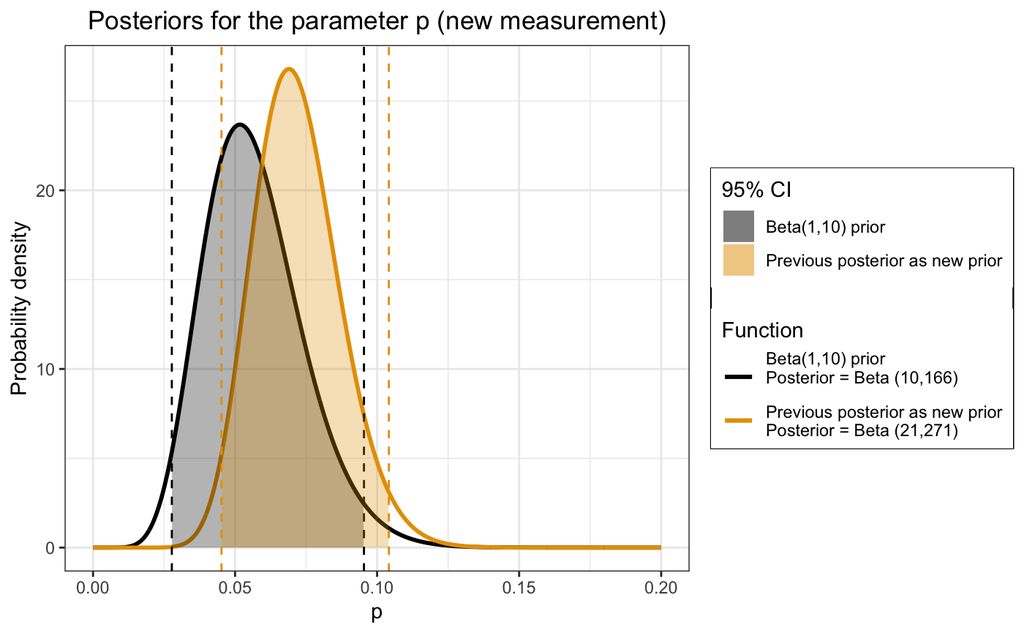

```r
# plot
plt3e_CI <- plt3e_post +
            geom_vline(xintercept = CI_3e_beta_B, colour=cbPalette[1], linetype="dashed") +
            geom_area(data=beta_post3e_df, alpha=0.3,
                      aes(x=ifelse(p>=CI_3e_beta_B[1] & p<=CI_3e_beta_B[2], p, NA),
                          fill=paste0("Beta(", a3_beta_prior, ",", b3_beta_prior, ") prior"))) +
            geom_vline(xintercept = CI_3e_new_B, colour=cbPalette[2], linetype="dashed") +
            geom_area(data=new_post3e_df, alpha=0.3,
                      aes(x=ifelse(p>=CI_3e_new_B[1] & p<=CI_3e_new_B[2], p, NA),
                          fill="Previous posterior as new prior")) +
            labs(fill="95% CI") +
            scale_fill_manual(values=cbPalette)

plt3e_CI
```

### Exercise 3h

Test the hypotesis
$$H_0 : p = 0.1 \text{
versus } H_1 : p \neq 0.1$$
at 5% level of significance with both the frequentist and Bayesian approach.

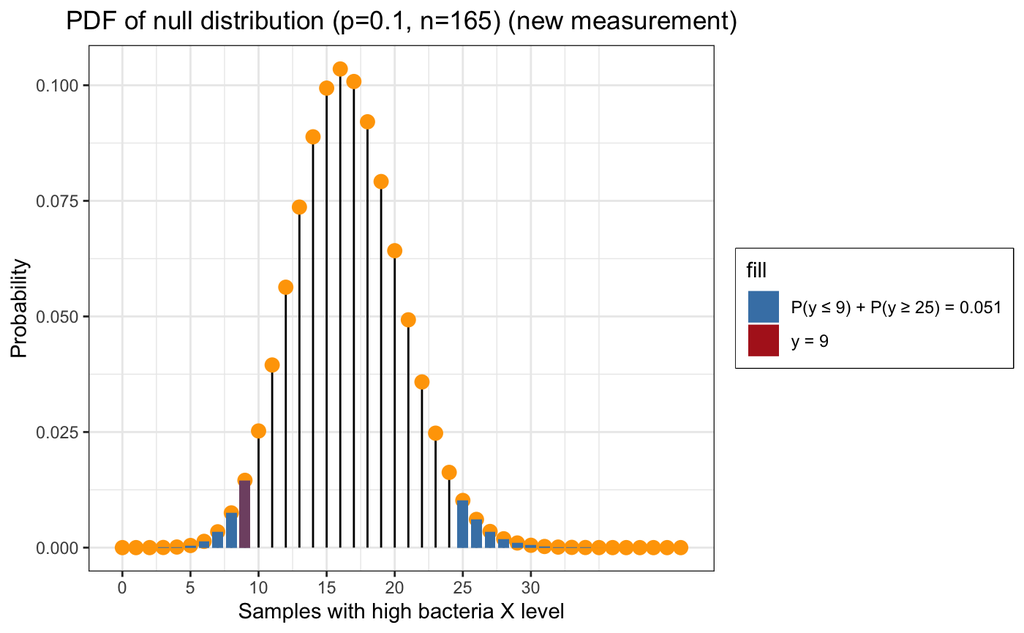

```r
# frequentist hypothesis testing
# these extreme values are the first ones belonging to the rejection region
CI_3e_F <- c(qbinom(0.025, size=n3e, prob=0.1), qbinom(0.975, size=n3e, prob=0.1)+1)
signif_3e_F <- pbinom(CI_3e_F[1], size=n3e, prob=0.1) + pbinom(CI_3e_F[2]-1, size=n3e, prob=0.1, lower.tail=FALSE)

# plot
null_distr3e <- tibble(x=seq(from=0, to=n3e/4), y=dbinom(x=seq(from=0, to=n3e/4), size=n3e, prob=0.1))
plt3e_pval_F <- ggplot(data=null_distr3e, mapping=aes(x=x, y=y)) +
                labs(title=paste0("PDF of null distribution (p=0.1, n=", n3e, ") (new measurement)"), fill="fill") +
                geom_segment(aes(x=x, xend=x, y=0, yend=y)) +
                geom_point(size=3, color='orange') +
                geom_col(mapping=aes(x=ifelse((x<=CI_3e_F[1] | x>=CI_3e_F[2]), x, 0),
                                     y=ifelse((x<=CI_3e_F[1] | x>=CI_3e_F[2]), y, 0),
                                     fill=paste0("P(y ≤ ", CI_3e_F[1], ") + P(y ≥ ", CI_3e_F[2], ") = ", round(signif_3e_F,3))),
                         alpha=1, size=0.5, width = 0.8) +
                geom_col(data=tibble(x=y3e, y=dbinom(y3e, size=n3e, prob=0.1)), mapping=aes(fill=paste0("y = ", y3e)),
                         alpha=0.5, size=0.5, width = 0.8) +
                scale_x_continuous(name ="Samples with high bacteria X level", breaks=seq(0,30,5)) +
                scale_y_continuous(name ="Probability") +
                scale_fill_manual(values=c("steelblue", "firebrick")) +
                theme_bw() +
                theme(plot.title=element_text(hjust=0.5), legend.box.background = element_rect(size=0.4))
plt3e_pval_F
```

**Since the value of $y=9$ is outside the 95% frequentist confidence interval, we reject the null hypothesis at 5% level of significance in the frequentist approach. In the Bayesian hypothesis testing, instead, we employ the 95% credibility interval computed in the previous point (3c) considering both the case with a Beta(1,10) prior and the prior obtained from the previous posterior. The value of $p=0.1$ lies outside the acceptance region with a Beta(1,10) prior, while it lies inside the acceptance region with the prior obtained from the previous posterior. In this case the acceptance or rejection of the null hypothesis depends on the prior that is chosen. By not considering the previous data (i.e., using a Beta(1,10) prior) we conclude that the parameter $p=0.1$ is not in the posterior’s 95% credibility interval, while using both the actual data and the previous data($y/n=9/165$ and $y/n=11/116$, respectively) we conclude that the parameter $p=0.1$ is actually in the posterior’s 95% credibility interval.**

## Exercise 4

Analyze the data of Exercise 1 using a MCMC with JAGS.

```r
# model definition
data4 <- NULL
data4$a_prior <- a1_prior
data4$b_prior <- b1_prior
data4$X <- y1
data4$n <- n1

# model computations
jm4 <- jags.model("model4.bug", data4, n.adapt=1000, quiet=TRUE)
chain4 <- coda.samples(jm4, c("p"), n.iter=10000, progress.bar="none")
print(summary(chain4))
```

```
Iterations = 1001:11000
Thinning interval = 1
Number of chains = 1
Sample size per chain = 10000

1. Empirical mean and standard deviation for each variable,
   plus standard error of the mean:

          Mean             SD       Naive SE Time-series SE
     0.0845650      0.0307556      0.0003076      0.0004294

2. Quantiles for each variable:

   2.5%     25%     50%     75%   97.5%
0.03477 0.06256 0.08113 0.10262 0.15560
```

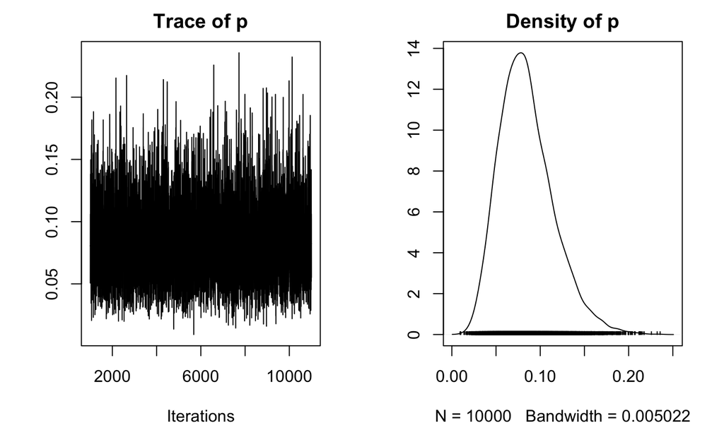

```r
plot(chain4)
```

```r
mean_4_post <- unname(summary(chain4)$statistics["Mean"])
sd_4_post <- unname(summary(chain4)$statistics["SD"])
CI_1_post <- c(qbeta(0.025, a1_post, b1_post), qbeta(0.975, a1_post, b1_post))
CI_4_post <- unname(summary(chain4)$quantiles[c("2.5%","97.5%")])

cat(
  "Mean computed by JAGS = ", signif(mean_4_post,4), "\n",
  "Mean computed (analytically) in point 1 = ", signif(mean_beta1_post,4), "\n",

  "-----------\n",

  "Variance computed by JAGS = ", signif(sd_4_post**2,4), "\n",
  "Variance computed (analytically) in point 1 = ", signif(var_beta1_post,4), "\n",

  "-----------\n",

  "95% credibility interval computed by JAGS = [", signif(CI_1_post[1],3), ",", signif(CI_1_post[2],3), "]\n",
  "95% credibility interval computed in point 1 = [", signif(CI_4_post[1],3), ",", signif(CI_4_post[2],3), "]\n",

  sep="")
```

[output not shown]

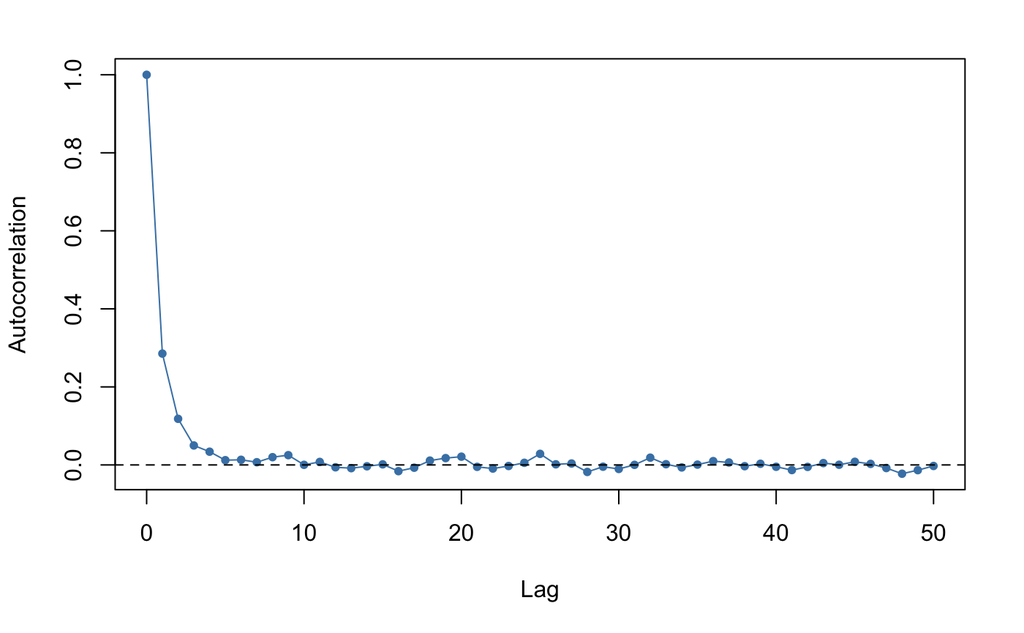

```r
# plot autocorrelation
l = c(0:50)
plot(x=l, y=unname(autocorr(chain4, lags=l))[[1]], type = 'o', pch = 20, col = "steelblue", cex = 1, lwd = 1,
     main = "", xlab = "Lag", ylab = "Autocorrelation")
abline(h=0, lty="dashed")
```

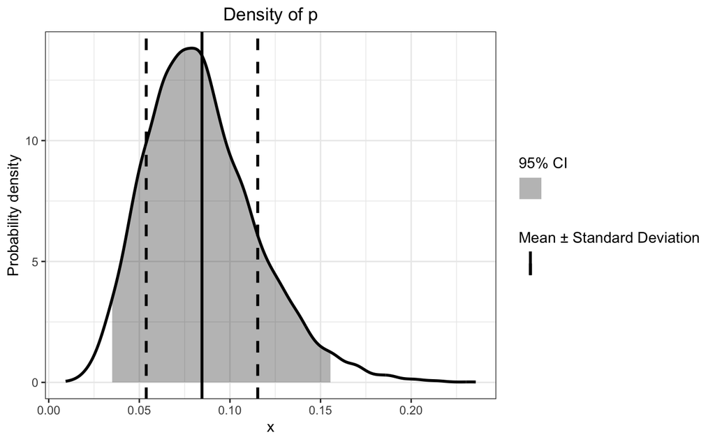

```r
# retrieve data from density plot
density4_df <- ggplot_build(ggplot() + geom_density(data=as_tibble(as.mcmc(chain4)), mapping=aes(x=p)))$data[[1]][c("x","y")]

# plot
plt4 <- ggplot() +
        geom_line(mapping=aes(x=x, y=y), data=density4_df, size=1) +
        geom_vline(mapping=aes(xintercept=mean_4_post, color=""), size=1) +
        geom_vline(mapping=aes(xintercept=c(mean_4_post+sd_4_post,mean_4_post-sd_4_post), color=""), linetype="dashed", size=1) +
        geom_area(data=density4_df,
                  aes(x=ifelse(x>=CI_4_post[1] & x<=CI_4_post[2], x, NA), fill="", y=y),
                  alpha=0.3) +
        labs(title="Density of p") +
        scale_y_continuous(name="Probability density") +
        scale_fill_manual(values=cbPalette[1], name="95% CI") +
        scale_colour_manual(values=rep(cbPalette,2), name="Mean ± Standard Deviation") +
        theme_bw() +
        theme(plot.title=element_text(hjust=0.5))

plt4
```

## Exercise 5

Analyze the data of Exercise 2 using a MCMC with JAGS.

**Analysis with uniform prior**

```r
# model definition: corp1+corp2, uniform prior
data5_corp1_u <- NULL
data5_corp1_u$X <- data2_corp1
data5_corp2_u <- NULL
data5_corp2_u$X <- data2_corp2

# model computations: corp1+corp2, uniform prior
jm5_corp1_u <- jags.model("model5_u.bug", data5_corp1_u, quiet = TRUE)
update(jm5_corp1_u, 1000, progress.bar="none")
chain5_corp1_u <- coda.samples(jm5_corp1_u, c("lambda"), n.iter=10000, progress.bar="none")

jm5_corp2_u <- jags.model("model5_u.bug", data5_corp2_u, quiet = TRUE)
update(jm5_corp2_u, 1000, progress.bar="none")
chain5_corp2_u <- coda.samples(jm5_corp2_u, c("lambda"), n.iter=10000, progress.bar="none")
```

```r
cat("Corp 1:\n")
```

```
Corp 1:
```

```r
print(summary(chain5_corp1_u))
```

```
Iterations = 1001:11000
Thinning interval = 1
Number of chains = 1
Sample size per chain = 10000

1. Empirical mean and standard deviation for each variable,
   plus standard error of the mean:

          Mean             SD       Naive SE Time-series SE
     0.6141092      0.0559857      0.0005599      0.0005710

2. Quantiles for each variable:

  2.5%    25%    50%    75%  97.5%
0.5098 0.5757 0.6121 0.6504 0.7295
```

```r
cat("\n\n------------\n\n")
cat("Corp 2:\n")
```

```
Corp 2:
```

```r
print(summary(chain5_corp2_u))
```

```
Iterations = 1001:11000
Thinning interval = 1
Number of chains = 1
Sample size per chain = 10000

1. Empirical mean and standard deviation for each variable,
   plus standard error of the mean:

          Mean             SD       Naive SE Time-series SE
        0.7039         0.0500         0.0005         0.0005

2. Quantiles for each variable:

  2.5%    25%    50%    75%  97.5%
0.6094 0.6693 0.7028 0.7368 0.8066
```

```r
# plot autocorrelations
l = c(0:50)
par(mfrow=c(1, 2), mar=c(4,4,4,2))

plot(x=l, y=unname(autocorr(chain5_corp1_u, lags=l))[[1]], type = 'o', pch = 20, col = "steelblue", cex = 1, lwd = 1,
     main = "Corp 1, uniform prior", xlab = "Lag", ylab = "Autocorrelation")
abline(h=0, lty="dashed")
```

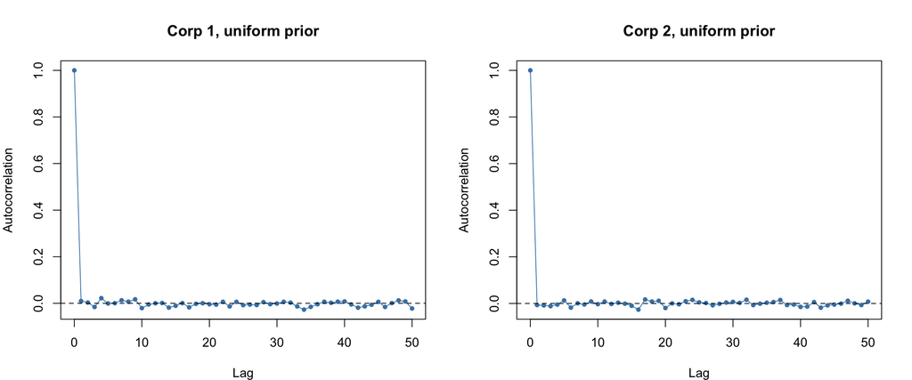

```r
plot(x=l, y=unname(autocorr(chain5_corp2_u, lags=l))[[1]], type = 'o', pch = 20, col = "steelblue", cex = 1, lwd = 1,
     main = "Corp 2, uniform prior", xlab = "Lag", ylab = "Autocorrelation")
abline(h=0, lty="dashed")
```

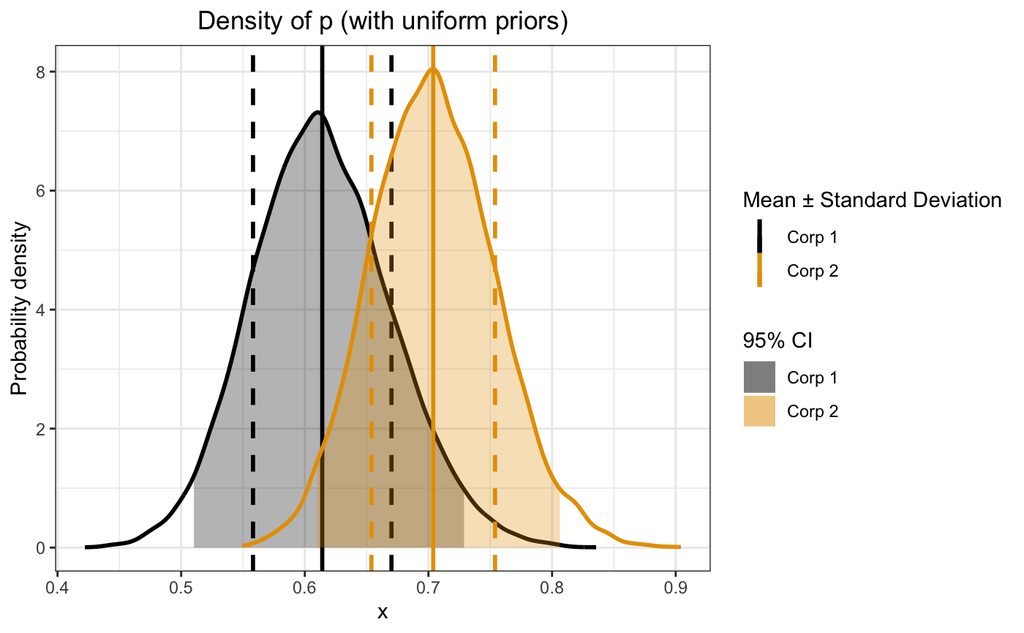

```r
# mean and std dev
mean_5_corp1_u_post <- unname(summary(chain5_corp1_u)$statistics["Mean"])
sd_5_corp1_u_post <- unname(summary(chain5_corp1_u)$statistics["SD"])
mean_5_corp2_u_post <- unname(summary(chain5_corp2_u)$statistics["Mean"])
sd_5_corp2_u_post <- unname(summary(chain5_corp2_u)$statistics["SD"])
CI_5_corp1_u_post <- unname(summary(chain5_corp1_u)$quantiles[c("2.5%","97.5%")])
CI_5_corp2_u_post <- unname(summary(chain5_corp2_u)$quantiles[c("2.5%","97.5%")])

# retrieve data from density plot
density5_corp1_u_df <- ggplot_build(ggplot() + geom_density(data=as_tibble(as.mcmc(chain5_corp1_u)), mapping=aes(x=lambda)))$data[[1]][c("x","y")]
density5_corp2_u_df <- ggplot_build(ggplot() + geom_density(data=as_tibble(as.mcmc(chain5_corp2_u)), mapping=aes(x=lambda)))$data[[1]][c("x","y")]

# plot
plt5_u <- ggplot() +
          geom_line(mapping=aes(x=x, y=y), data=density5_corp1_u_df, size=1, color=cbPalette[1]) +
          geom_vline(mapping=aes(xintercept=mean_5_corp1_u_post, color="Corp 1"), size=1) +
          geom_vline(mapping=aes(xintercept=c(mean_5_corp1_u_post+sd_5_corp1_u_post,mean_5_corp1_u_post-sd_5_corp1_u_post),color="Corp 1"),
                     linetype="dashed", size=1) +
          geom_area(data=density5_corp1_u_df, alpha=0.3,
                    aes(x=ifelse(x>=CI_5_corp1_u_post[1] & x<=CI_5_corp1_u_post[2], x, NA), fill="Corp 1", y=y)) +
          geom_line(mapping=aes(x=x, y=y), data=density5_corp2_u_df, size=1, color=cbPalette[2]) +
          geom_vline(mapping=aes(xintercept=mean_5_corp2_u_post, color="Corp 2"), size=1) +
          geom_vline(mapping=aes(xintercept=c(mean_5_corp2_u_post+sd_5_corp2_u_post,mean_5_corp2_u_post-sd_5_corp2_u_post),color="Corp 2"),
                     linetype="dashed", size=1) +
          geom_area(data=density5_corp2_u_df, alpha=0.3,
                    aes(x=ifelse(x>=CI_5_corp2_u_post[1] & x<=CI_5_corp2_u_post[2], x, NA), fill="Corp 2", y=y)) +
          labs(title="Density of p (with uniform priors)") +
          scale_y_continuous(name="Probability density") +
          scale_fill_manual(values=cbPalette, name="95% CI") +
          scale_colour_manual(values=rep(cbPalette,2), name="Mean ± Standard Deviation") +
          theme_bw() +
          theme(plot.title=element_text(hjust=0.5))

plt5_u
```

**Analysis with Jeffrey’s prior**

```r
# model definition: corp1+corp2, Jeffrey's prior
data5_corp1_J <- NULL
data5_corp1_J$X <- data2_corp1
data5_corp2_J <- NULL
data5_corp2_J$X <- data2_corp2

# model computations: corp1+corp2, Jeffrey's prior
jm5_corp1_J <- jags.model("model5_J.bug", data5_corp1_J, quiet = TRUE)
update(jm5_corp1_J, 1000, progress.bar="none")
chain5_corp1_J <- coda.samples(jm5_corp1_J, c("lambda"), n.iter=10000, progress.bar="none")

jm5_corp2_J <- jags.model("model5_J.bug", data5_corp2_J, quiet = TRUE)
update(jm5_corp2_J, 1000, progress.bar="none")
chain5_corp2_J <- coda.samples(jm5_corp2_J, c("lambda"), n.iter=10000, progress.bar="none")
```

```r
cat("Corp 1:\n")
```

```
Corp 1:
```

```r
print(summary(chain5_corp1_J))
```

```
Iterations = 1001:11000
Thinning interval = 1
Number of chains = 1
Sample size per chain = 10000

1. Empirical mean and standard deviation for each variable,
   plus standard error of the mean:

          Mean             SD       Naive SE Time-series SE
     0.6125693      0.0549796      0.0005498      0.0005498

2. Quantiles for each variable:

  2.5%    25%    50%    75%  97.5%
0.5099 0.5746 0.6107 0.6490 0.7256
```

```r
cat("\n\n------------\n\n")
cat("Corp 2:\n")
```

```
Corp 2:
```

```r
print(summary(chain5_corp2_J))
```

```
Iterations = 1001:11000
Thinning interval = 1
Number of chains = 1
Sample size per chain = 10000

1. Empirical mean and standard deviation for each variable,
   plus standard error of the mean:

          Mean             SD       Naive SE Time-series SE
     0.7027173      0.0501683      0.0005017      0.0005076

2. Quantiles for each variable:

  2.5%    25%    50%    75%  97.5%
0.6077 0.6684 0.7015 0.7362 0.8043
```

```r
# plot autocorrelations
l = c(0:50)
par(mfrow=c(1, 2), mar=c(4,4,4,2))

plot(x=l, y=unname(autocorr(chain5_corp1_J, lags=l))[[1]], type = 'o', pch = 20, col = "steelblue", cex = 1, lwd = 1,
     main = "Corp 1, Jeffrey's prior", xlab = "Lag", ylab = "Autocorrelation")
abline(h=0, lty="dashed")
```

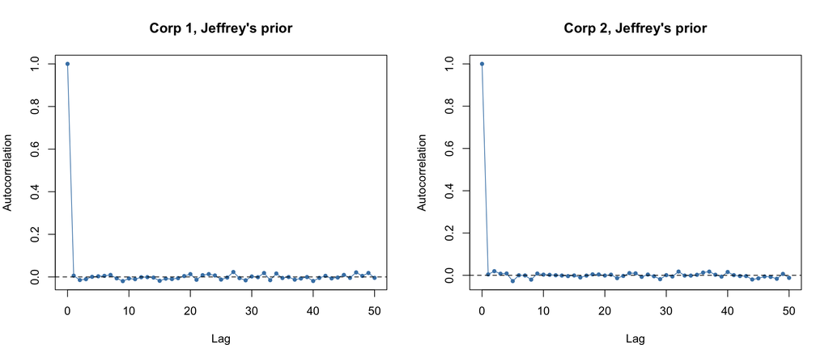

```r
plot(x=l, y=unname(autocorr(chain5_corp2_J, lags=l))[[1]], type = 'o', pch = 20, col = "steelblue", cex = 1, lwd = 1,
     main = "Corp 2, Jeffrey's prior", xlab = "Lag", ylab = "Autocorrelation")
abline(h=0, lty="dashed")
```

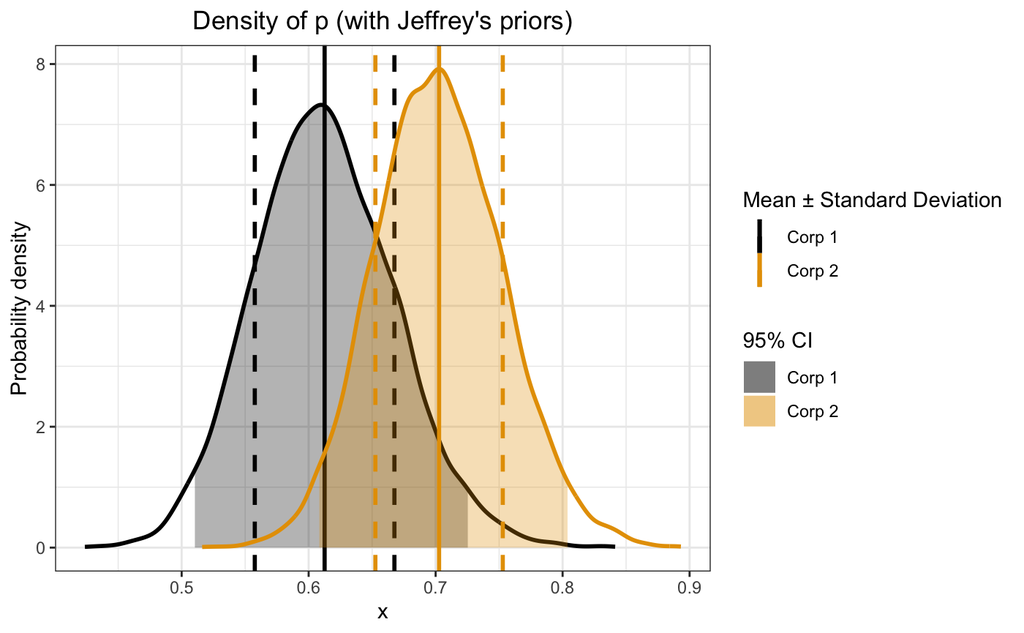

```r
# mean and std dev
mean_5_corp1_J_post <- unname(summary(chain5_corp1_J)$statistics["Mean"])
sd_5_corp1_J_post <- unname(summary(chain5_corp1_J)$statistics["SD"])
mean_5_corp2_J_post <- unname(summary(chain5_corp2_J)$statistics["Mean"])
sd_5_corp2_J_post <- unname(summary(chain5_corp2_J)$statistics["SD"])
CI_5_corp1_J_post <- unname(summary(chain5_corp1_J)$quantiles[c("2.5%","97.5%")])
CI_5_corp2_J_post <- unname(summary(chain5_corp2_J)$quantiles[c("2.5%","97.5%")])

# retrieve data from density plot
density5_corp1_J_df <- ggplot_build(ggplot() + geom_density(data=as_tibble(as.mcmc(chain5_corp1_J)), mapping=aes(x=lambda)))$data[[1]][c("x","y")]
density5_corp2_J_df <- ggplot_build(ggplot() + geom_density(data=as_tibble(as.mcmc(chain5_corp2_J)), mapping=aes(x=lambda)))$data[[1]][c("x","y")]

# plot
plt5_J <- ggplot() +
          geom_line(mapping=aes(x=x, y=y), data=density5_corp1_J_df, size=1, color=cbPalette[1]) +
          geom_vline(mapping=aes(xintercept=mean_5_corp1_J_post, color="Corp 1"), size=1) +
          geom_vline(mapping=aes(xintercept=c(mean_5_corp1_J_post+sd_5_corp1_J_post,mean_5_corp1_J_post-sd_5_corp1_J_post),color="Corp 1"),
                     linetype="dashed", size=1) +
          geom_area(data=density5_corp1_J_df, alpha=0.3,
                    aes(x=ifelse(x>=CI_5_corp1_J_post[1] & x<=CI_5_corp1_J_post[2], x, NA), fill="Corp 1", y=y)) +
          geom_line(mapping=aes(x=x, y=y), data=density5_corp2_J_df, size=1, color=cbPalette[2]) +
          geom_vline(mapping=aes(xintercept=mean_5_corp2_J_post, color="Corp 2"), size=1) +
          geom_vline(mapping=aes(xintercept=c(mean_5_corp2_J_post+sd_5_corp2_J_post,mean_5_corp2_J_post-sd_5_corp2_J_post),color="Corp 2"),
                     linetype="dashed", size=1) +
          geom_area(data=density5_corp2_J_df, alpha=0.3,
                    aes(x=ifelse(x>=CI_5_corp2_J_post[1] & x<=CI_5_corp2_J_post[2], x, NA), fill="Corp 2", y=y)) +
          labs(title="Density of p (with Jeffrey's priors)") +
          scale_y_continuous(name="Probability density") +
          scale_fill_manual(values=cbPalette, name="95% CI") +
          scale_colour_manual(values=rep(cbPalette,2), name="Mean ± Standard Deviation") +
          theme_bw() +
          theme(plot.title=element_text(hjust=0.5))

plt5_J
```

## Exercise 6

Analyze the data of Exercise 3 using a MCMC with JAGS.

```r
# model definition
data6 <- NULL
data6$a_prior <- a3_beta_prior
data6$b_prior <- b3_beta_prior
data6$X <- y3a
data6$n <- n3a

# model computations
jm6 <- jags.model("model6.bug", data6, n.adapt=1000, quiet=TRUE)
chain6 <- coda.samples(jm6, c("p"), n.iter=10000, progress.bar="none")
print(summary(chain6))
```

```
Iterations = 1001:11000
Thinning interval = 1
Number of chains = 1
Sample size per chain = 10000

1. Empirical mean and standard deviation for each variable,
   plus standard error of the mean:

          Mean             SD       Naive SE Time-series SE
     0.0941223      0.0258956      0.0002590      0.0003389

2. Quantiles for each variable:

   2.5%     25%     50%     75%   97.5%
0.04985 0.07590 0.09177 0.10963 0.15141
```

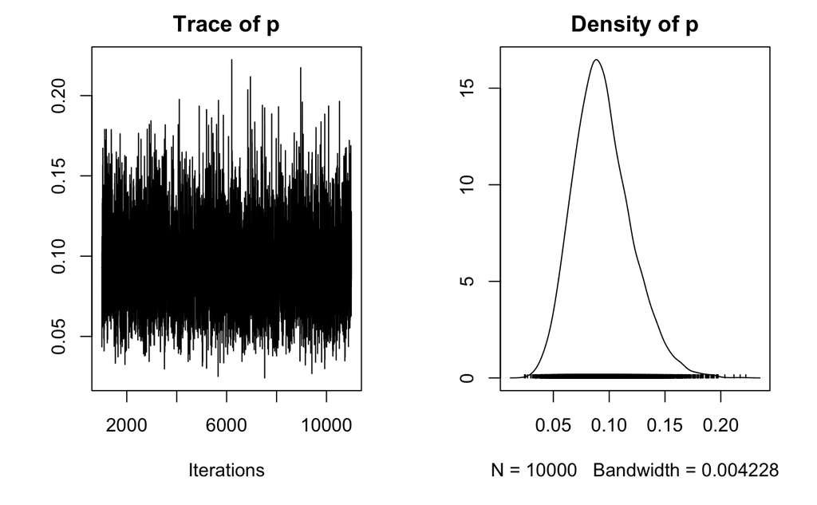

```r
plot(chain6)
```

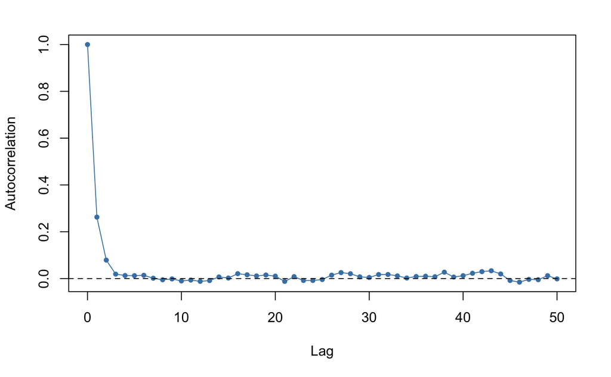

```r
# plot autocorrelation
l = c(0:50)
plot(x=l, y=unname(autocorr(chain6, lags=l))[[1]], type = 'o', pch = 20, col = "steelblue", cex = 1, lwd = 1,
     main = "", xlab = "Lag", ylab = "Autocorrelation")
abline(h=0, lty="dashed")
```

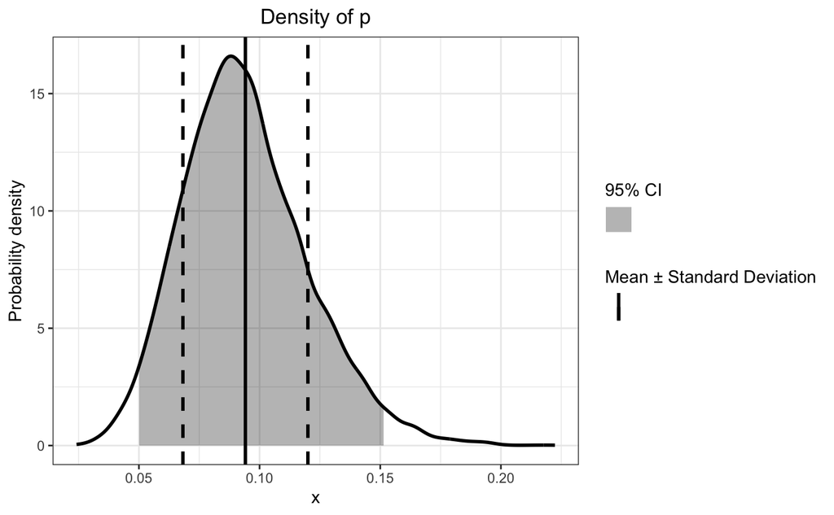

```r
# mean and std dev
mean_6_post <- unname(summary(chain6)$statistics["Mean"])
sd_6_post <- unname(summary(chain6)$statistics["SD"])
CI_6_post <- unname(summary(chain6)$quantiles[c("2.5%","97.5%")])

# retrieve data from density plot
density6_df <- ggplot_build(ggplot() + geom_density(data=as_tibble(as.mcmc(chain6)), mapping=aes(x=p)))$data[[1]][c("x","y")]

# plot
plt6 <- ggplot() +
        geom_line(mapping=aes(x=x, y=y), data=density6_df, size=1, color=cbPalette[1]) +
        geom_vline(mapping=aes(xintercept=mean_6_post, color=""), size=1) +
        geom_vline(mapping=aes(xintercept=c(mean_6_post+sd_6_post,mean_6_post-sd_6_post),color=""),
                   linetype="dashed", size=1) +
        geom_area(data=density6_df, alpha=0.3,
                  aes(x=ifelse(x>=CI_6_post[1] & x<=CI_6_post[2], x, NA), fill="", y=y)) +
        labs(title="Density of p") +
        scale_y_continuous(name="Probability density") +
        scale_fill_manual(values=cbPalette, name="95% CI") +
        scale_colour_manual(values=rep(cbPalette,2), name="Mean ± Standard Deviation") +
        theme_bw() +
        theme(plot.title=element_text(hjust=0.5))

plt6
```